# Data Science for Public Policy

Assignment 04

Author

David Bluhm - db1597

D.C. Capital Bikeshare Data Visualizations

All data sourced from  
[Capital Bikeshare](https://s3.amazonaws.com/capitalbikeshare-data/index.html)

# Data Set-Up

```r
library(tidyverse)
library(lubridate)
library(readr)
library(sf)
library(tigris)
library(crsuggest)

cabi_jan <- read_csv("data/202501-capitalbikeshare-tripdata.csv")

cabi_jul <- read_csv("data/202407-capitalbikeshare-tripdata.csv")

cabi_combined <- rbind(cabi_jan, cabi_jul)

cabi_combined$started_at <- as.POSIXct(cabi_combined$started_at)

cabi_combined <- cabi_combined |>
  mutate(month = if_else(year(started_at) == 2025, "January", "July"))
```

# Visualization 1

Classic vs. E-Bike Breakdown over January

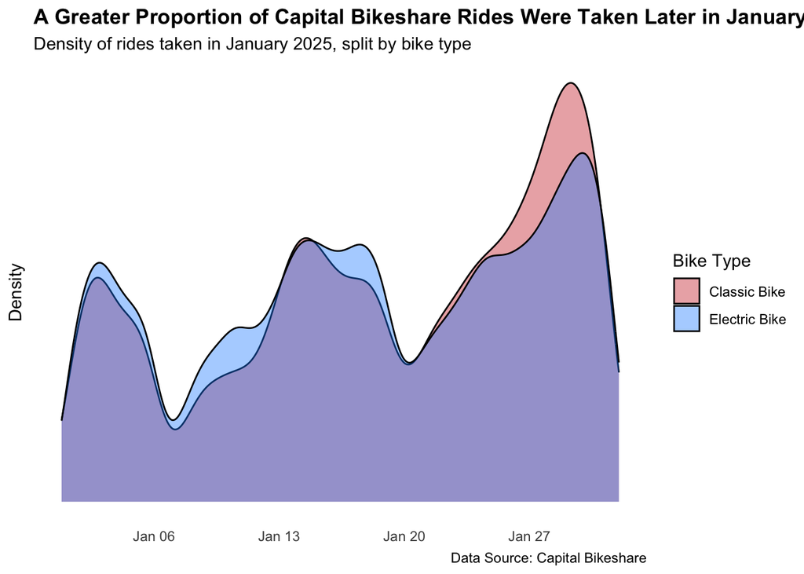

```r
cabi_jan |>
  ggplot(mapping = aes(x = started_at))+
  geom_density(mapping = aes(fill = rideable_type),
               alpha = .4)+
  scale_fill_manual(values = c("electric_bike" = "dodgerblue",
                               "classic_bike" = "firebrick3"),
                    labels = c("electric_bike" = "Electric Bike",
                               "classic_bike" = "Classic Bike"))+
  labs(title = "A Greater Proportion of Capital Bikeshare Rides Were Taken Later in January",
       subtitle = "Density of rides taken in January 2025, split by bike type",
       caption = "Data Source: Capital Bikeshare",
       fill = "Bike Type",
       y = "Density")+
  theme_minimal()+
  theme(
    plot.title = element_text(face = "bold"),
    axis.title.x = element_blank(),
    axis.text.y = element_blank(),
    panel.grid.major = element_blank(),
    panel.grid.minor = element_blank())
```

# Visualization 2

Stacked bar by days of week

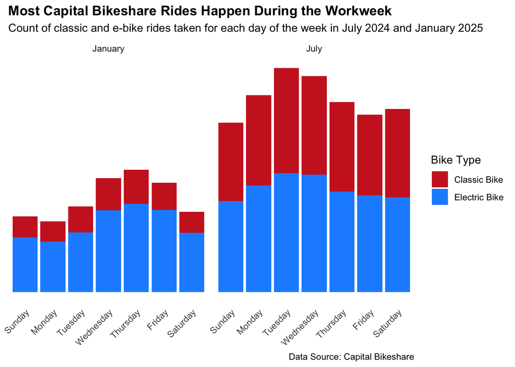

```r
cabi_combined <- cabi_combined |>
  mutate(day_of_week = weekdays(started_at))

cabi_combined$day_of_week <- factor(cabi_combined$day_of_week, levels = c("Sunday","Monday", "Tuesday", "Wednesday", "Thursday", "Friday", "Saturday"))

cabi_counts <- cabi_combined |>
  group_by(month, day_of_week, rideable_type) |>
  summarise(count = n())

cabi_counts |>
  ggplot(mapping = aes(x = day_of_week,
                       y = count,
                       fill = rideable_type)) +
  geom_bar(stat = "identity") +
    scale_fill_manual(values = c("electric_bike" = "dodgerblue",
                               "classic_bike" = "firebrick3"),
                    labels = c("electric_bike" = "Electric Bike",
                               "classic_bike" = "Classic Bike"))+
  labs(title = "Most Capital Bikeshare Rides Happen During the Workweek",
       subtitle = "Count of classic and e-bike rides taken for each day of the week in July 2024 and January 2025",
       caption = "Data Source: Capital Bikeshare",
       fill = "Bike Type")+
  theme_minimal()+
  theme(
    plot.title = element_text(face = "bold"),
    axis.title.x = element_blank(),
    axis.text.x = element_text(angle = 45, hjust = 1, vjust = 1),
    axis.title.y = element_blank(),
    axis.text.y = element_blank(),
    panel.grid.major = element_blank(),
    panel.grid.minor = element_blank()) +
  facet_wrap(~month)
```

This visualization shows how Capital Bikeshare ridership varies throughout the week. For both summer and winter months the peak day of the week is during the workweek, showing that many people use Capital Bikeshare for their commute. Policymakers can utilize this information to make additional preparations during the these specific weekdays when more people are riding, like ensuring bikes are distributed to all stations and having prompt pickups for broken bikes that have had maintenance requests. This would help make biking a viable transit option for more D.C. residents.

# Visualization 3

Time of day line graph

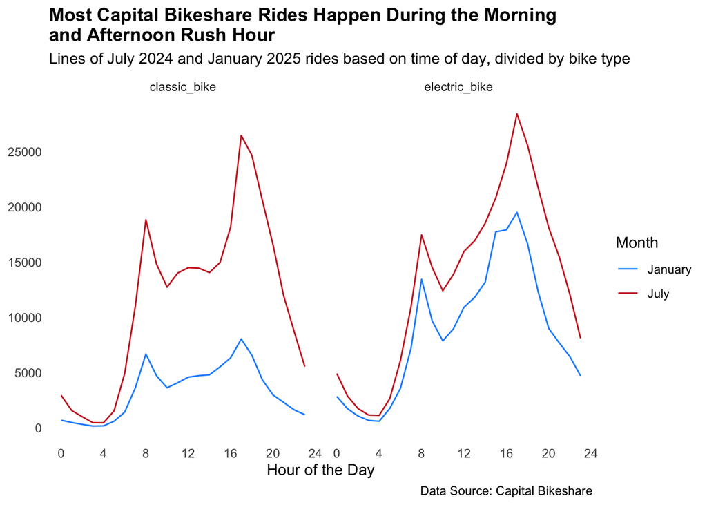

```r
cabi_combined <- cabi_combined |>
  mutate(time_of_day = hour(started_at))

cabi_tod <- cabi_combined |>
  group_by(month, time_of_day, rideable_type) |>
  summarise(count = n())

cabi_tod |>
  ggplot(mapping = aes(x = time_of_day,
                       y = count,
                       color = month)) +
  geom_line() +
  scale_color_manual(values = c("January" = "dodgerblue",
                               "July" = "firebrick3"),
                    labels = c("January" = "January",
                               "July" = "July")) +
    labs(title = "Most Capital Bikeshare Rides Happen During the Morning\nand Afternoon Rush Hour",
       subtitle = "Lines of July 2024 and January 2025 rides based on time of day, divided by bike type",
       caption = "Data Source: Capital Bikeshare",
       x = "Hour of the Day",
       color = "Month")+
  scale_x_continuous(breaks = seq(0,24, by = 4))+
  scale_y_continuous(breaks = seq(0,30000, by = 5000))+
  facet_wrap(~rideable_type)+
  theme_minimal()+
  theme(
    plot.title = element_text(face = "bold"),
    axis.title.y = element_blank(),
    panel.grid.major = element_blank(),
    panel.grid.minor = element_blank())
```

Building off the previous visualization showing that most trips take place during the work week, this graph looks at how many trips are taken at each hour of the day. For both classic and e-bikes there are peaks during the morning commute hours (7 to 9) and evening commute hours (5 to 7 PM, or 17 to 19). This applies for warm months like July and cold months like January, although there are less rides overall in January (especially for classic bikes). Policymakers can use this information to better serve bike-commuters in D.C. by doing things like dispatching additional traffic police to specifically watch for bicyclist safety during these peak times.

# Visualization 4

Map of where rides start

```r
DC_roads <- roads(state = "DC",
                  county = "District of Columbia")
```

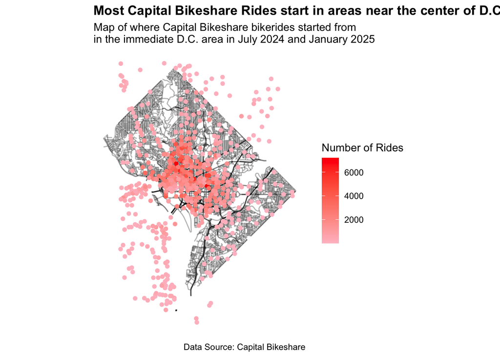

```r
cabi_map_dc <- cabi_combined |>
  filter(start_lat >= 38.6 & start_lat <= 39 & start_lng >= -77.1 & start_lng <= -76.9 & start_station_id != "") |>
group_by(start_station_id) |>
  summarise(count = n(),
            start_lat = first(start_lat),
            start_lng = first(start_lng))

cabi_map_dc <- st_as_sf(cabi_map_dc, coords = c("start_lng", "start_lat")) |>
  st_set_crs(value = 4326)

ggplot() +
  geom_sf(data = DC_roads,
          alpha = .3) +
  geom_sf(data = cabi_map_dc,
          mapping = aes(color = count)) +
  scale_color_gradient(low = "pink", high = "red") +
   labs(title = "Most Capital Bikeshare Rides start in areas near the center of D.C.",
       subtitle = paste("Map of where Capital Bikeshare bikerides started",
                        "from\nin the immediate D.C. area in July 2024 and January 2025"),
       caption = "Data Source: Capital Bikeshare",
       color = "Number of Rides")+
  theme_minimal()+
  theme(
    plot.title = element_text(face = "bold"),
    axis.title.y = element_blank(),
    axis.text.y = element_blank(),
    axis.text.x = element_blank(),
    panel.grid.major = element_blank(),
    panel.grid.minor = element_blank())
```

This visualization shows geographically where bikerides begin. A majority of activity happens in Wards 1, 2, and 6. With this data, policymakers can consider adding additional bike stations for these high-traffic areas, and can focus on ways to increase biking for the northern neighborhoods and East of the Anacostia.